# Multi-Label Classification

Viet Ba Mai, Shilpa Khichar

10 listopada 2016

# Multi-class classification

Most of classifiers are meant for binary classification. Below is a tutorial on how one can perform it having multiple classes.

# Data

The dataset was collected via National Indonesia Contraceptive Prevalence Survey. The features describe demographic and socio-economic characteristics of women that were either not pregnant or not aware of their pregnancy when interviewed. The target variable is `Contraceptive_Method` and represents 3 classes:

- [1] No use
- [2] Long-term methods
- [3] Short-term methods

# Data preparation and analysis

```r
library(caret)
library(ROCR)
library(klaR)
library(randomForest)
library(pROC)
library(corrplot)
library(magrittr)
library(plyr)
library(dplyr)
library(ggplot2)
library(e1071)

data <- read.csv(file="C:/Users/vietba/Downloads/contraceptive.csv", sep=",", encoding="UTF-8")
summary(data)
```

```
##     Wife_age     Wife_education  Husband_education    Children
##  Min.   :16.00   Min.   :1.000   Min.   :1.00      Min.   : 0.000
##  1st Qu.:26.00   1st Qu.:2.000   1st Qu.:3.00      1st Qu.: 1.000
##  Median :32.00   Median :3.000   Median :4.00      Median : 3.000
##  Mean   :32.54   Mean   :2.959   Mean   :3.43      Mean   : 3.261
##  3rd Qu.:39.00   3rd Qu.:4.000   3rd Qu.:4.00      3rd Qu.: 4.000
##  Max.   :49.00   Max.   :4.000   Max.   :4.00      Max.   :16.000
##  Wife_religion     Wife_working    Husband_occupation Standard.of.living
##  Min.   :0.0000   Min.   :0.0000   Min.   :1.000      Min.   :1.000
##  1st Qu.:1.0000   1st Qu.:0.0000   1st Qu.:1.000      1st Qu.:3.000
##  Median :1.0000   Median :1.0000   Median :2.000      Median :3.000
##  Mean   :0.8506   Mean   :0.7495   Mean   :2.138      Mean   :3.134
##  3rd Qu.:1.0000   3rd Qu.:1.0000   3rd Qu.:3.000      3rd Qu.:4.000
##  Max.   :1.0000   Max.   :1.0000   Max.   :4.000      Max.   :4.000
##  Media_exposure  Contraceptive_method
##  Min.   :0.000   Min.   :1.00
##  1st Qu.:0.000   1st Qu.:1.00
##  Median :0.000   Median :2.00
##  Mean   :0.074   Mean   :1.92
##  3rd Qu.:0.000   3rd Qu.:3.00
##  Max.   :1.000   Max.   :3.00
```

```r
data$Contraceptive_method <- factor(data$Contraceptive_method)
levels(data$Contraceptive_method)
```

```
## [1] "1" "2" "3"
```

```r
summary(data$Contraceptive_method)
```

```
##   1   2   3
## 629 333 511
```

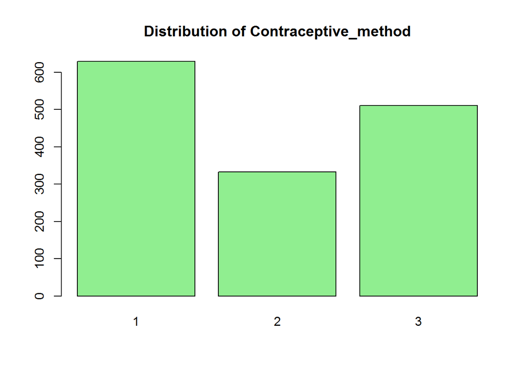

```r
barplot(table(data$Contraceptive_method), col="lightgreen", main="Distribution of Contraceptive_method")
```

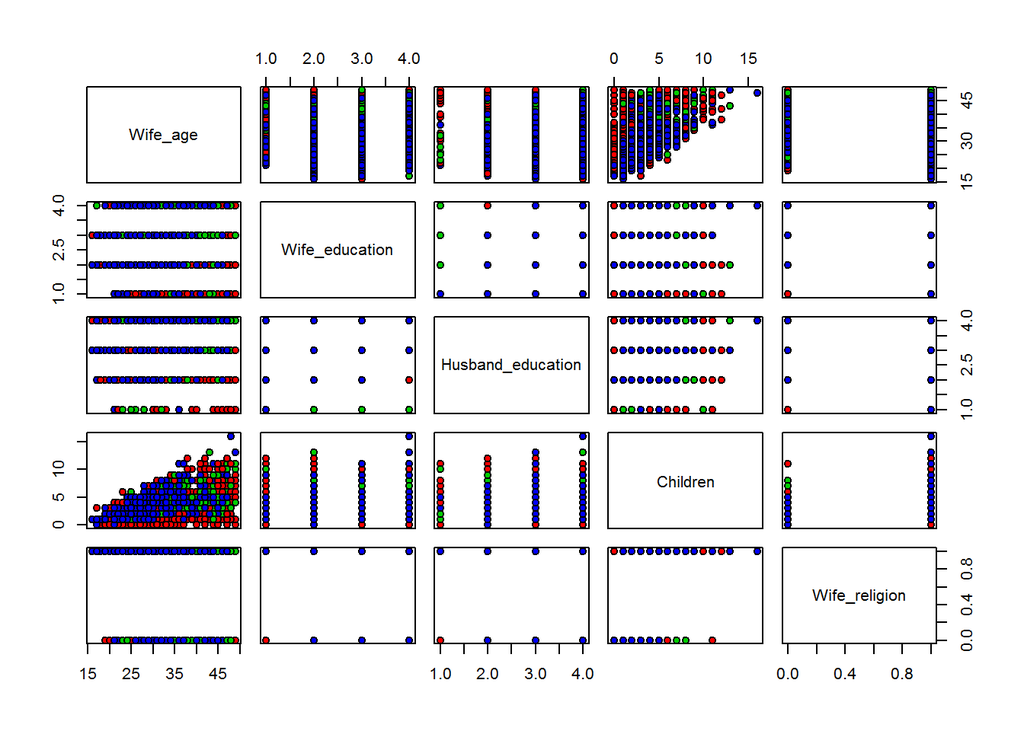

```r
pairs(data[1:5], pch = 21, bg = c("red", "green3","blue")[unclass(data$Contraceptive_method)])
```

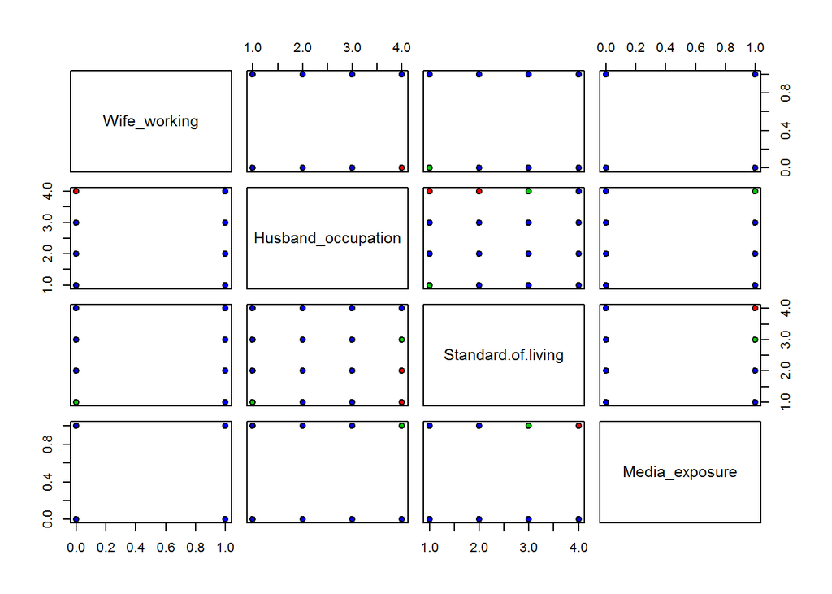

```r
pairs(data[6:9], pch = 21, bg = c("red", "green3","blue")[unclass(data$Contraceptive_method)])
```

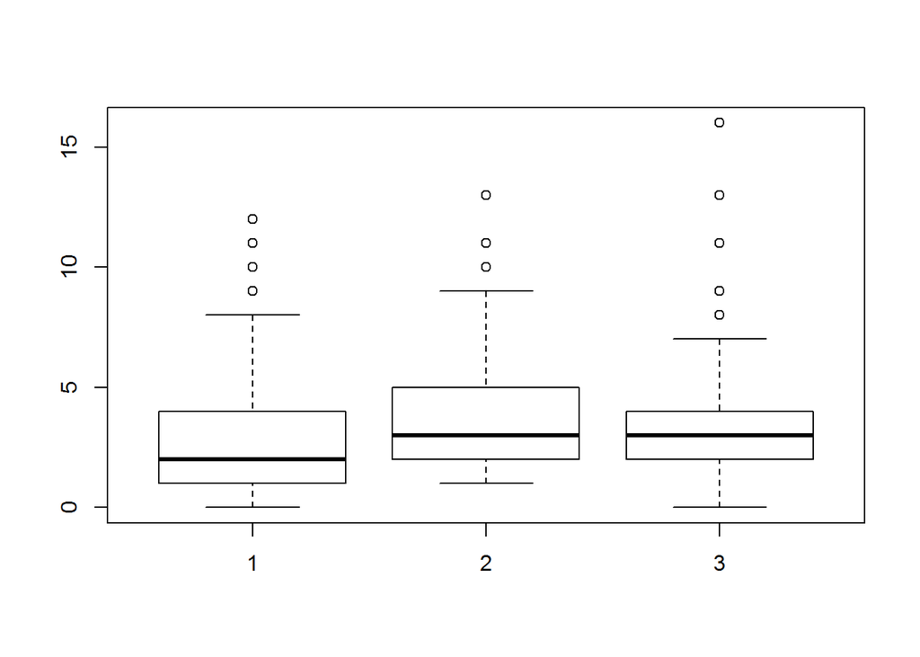

```r
boxplot(Children~Contraceptive_method, data=data)
```

```r
set.seed(1313)
indxTrain <- createDataPartition(y = data$Contraceptive_method, p = 0.75)
str(indxTrain)
```

```
## List of 1
##  $ Resample1: int [1:1106] 1 3 4 5 6 7 8 10 11 14 ...
```

```r
train <- data[indxTrain$Resample1,]
test <- data[-indxTrain$Resample1,]

summary(train$Contraceptive_method)
```

```
##   1   2   3
## 472 250 384
```

```r
summary(test$Contraceptive_method)
```

```
##   1   2   3
## 157  83 127
```

# SVM

Support Vector Machines are models applicable for binary tasks. However function `svm()` from library `e1071` can perform a multi-class classification directly.

The idea is that it permorms a **one-against-1one** classification - it trains binary classifiers for all pair combinations of target classes and the result is obtained by calculating the most voted classifier.

```r
svm.model=svm(Contraceptive_method~., data=train, kernel="polynomial",probability=TRUE)
svm.model
```

```
##
## Call:
## svm(formula = Contraceptive_method ~ ., data = train, kernel = "polynomial",
##     probability = TRUE)
##
##
## Parameters:
##    SVM-Type:  C-classification
##  SVM-Kernel:  polynomial
##        cost:  1
##      degree:  3
##       gamma:  0.1111111
##      coef.0:  0
##
## Number of Support Vectors:  980
```

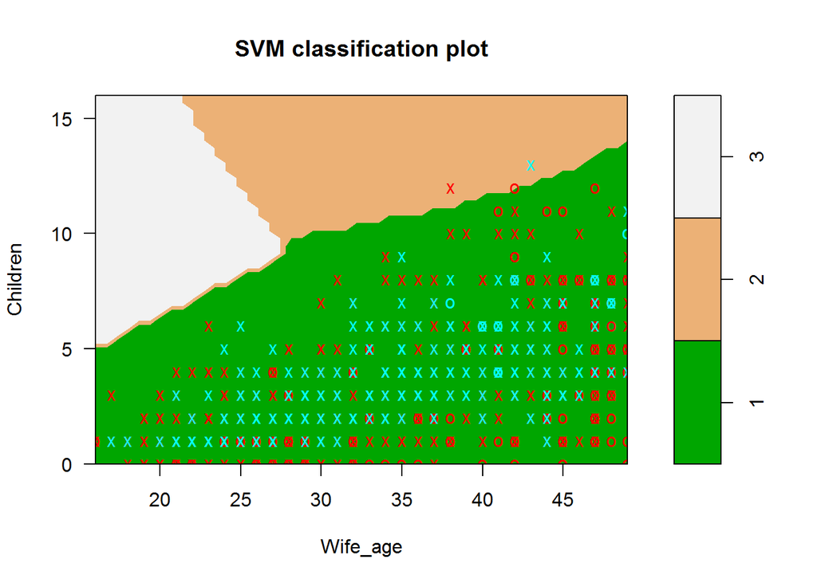

```r
plot(svm.model, train, Children ~ Wife_age,
     slice = list(Wife_education = 0, Husband_education = 1),
     svSymbol = "x", dataSymbol = "o", symbolPalette = rainbow(2),
     color.palette = terrain.colors,fill=TRUE)
```

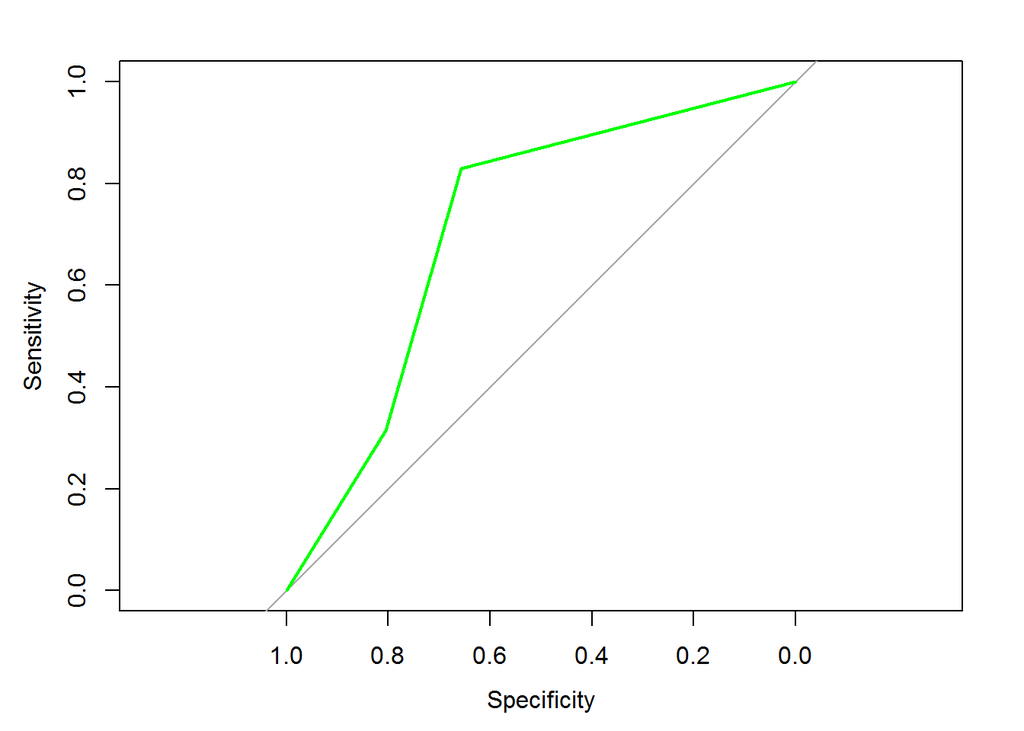

```
##
## Call:
## plot.roc.default(x = predSVM, predictor = as.numeric(test$Contraceptive_method),     col = "green")
##
## Data: as.numeric(test$Contraceptive_method) in 128 controls (predSVM 1) < 35 cases (predSVM 2).
## Area under the curve: 0.7155
```

```r
pred <- predict(svm.model, test, decision.values = TRUE, probability = TRUE)
predSVM <- predict(svm.model, test)
svmAUC <- auc(predSVM, as.numeric(test$Contraceptive_method))
plot.roc(predSVM, as.numeric(test$Contraceptive_method), col="green")
```

```r
summary(pred)
```

```
##   1   2   3
## 185  21 161
```

```r
head(attr(pred, "decision.values"))
```

```
##          1/2        1/3        2/3
## 2  1.7028086  1.4661425 -0.5246540
## 9  0.8843982 -0.4875683 -1.0601793
## 12 0.7282481  0.6240506 -0.1967105
## 13 0.8621018  1.5517382  1.3508404
## 15 0.8911770 -0.2540232 -0.9313755
## 20 4.8416419  3.5027235 -0.6080748
```

```r
head(attr(pred, "probabilities"))
```

```
##            1          2          3
## 2  0.6549014 0.15859616 0.18650248
## 9  0.3747464 0.19961979 0.42563385
## 12 0.4907325 0.24359614 0.26567131
## 13 0.5787970 0.27392655 0.14727643
## 15 0.4047429 0.20385916 0.39139796
## 20 0.9206607 0.02936357 0.04997568
```

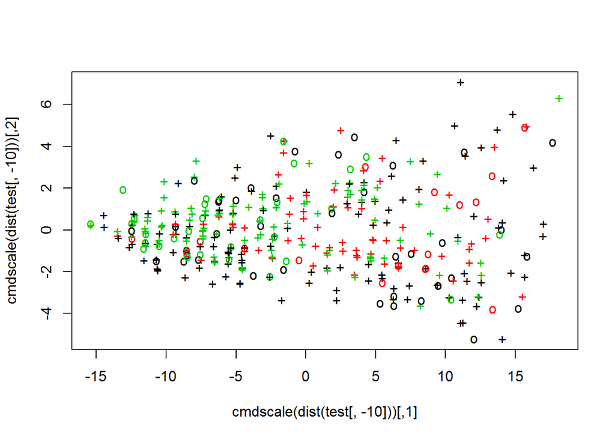

```r
# visualize (classes by color, SV by crosses):
#Multidimensional scaling takes a set of dissimilarities and returns a set of points such that the distances between the points are approximately equal to the dissimilarities.
plot(cmdscale(dist(test[,-10])),
     col = as.integer(test[,10]),
     pch = c("o","+")[1:150 %in% svm.model$index + 1])
```

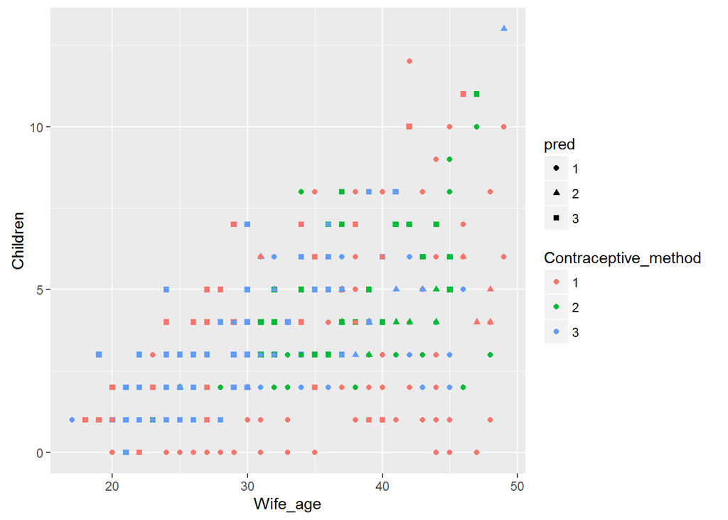

```r
mydf = cbind(test, pred)
qplot(Wife_age, Children, colour = Contraceptive_method, shape = pred, data = test)
```

# Random Forest

This is one of the most powerful learning tools and it is capable of performing classification on a large number of classes. There are many other such classifiers and using them can be the simplest approach since they can be applied directly on multiple classes.

Multiclass `ROC` curve can be plot with a prediction vector being calculated by traversing over the Random Forest’s prediction probabilities.

```r
rf = randomForest(Contraceptive_method ~ ., data = train, ntree = 100)
pr = predict(rf, test, type = 'prob')
myPr <- sapply(1:nrow(test), function(i){
  pr[i, test$Contraceptive_method[i]]
})
multiclass.roc(test$Contraceptive_method, myPr)
```

```
##
## Call:
## multiclass.roc.default(response = test$Contraceptive_method,     predictor = myPr)
##
## Data: myPr with 3 levels of test$Contraceptive_method: 1, 2, 3.
## Multi-class area under the curve: 0.6319
```

# Naive Bayes

We can check performance for each type in the class levels. Below `Area Under Curve` is calculated for classification done with `Naive Bayes` model (which is also a multi-class method).

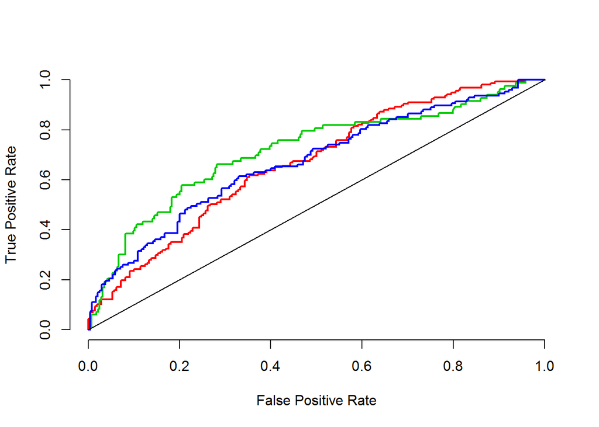

```r
lvls = levels(train$Contraceptive_method)
aucs = c()
plot(x=NA, y=NA, xlim=c(0,1), ylim=c(0,1),
     ylab='True Positive Rate',
     xlab='False Positive Rate',
     bty='n')

for (type.id in 1:3) {
  type.id
  type = as.factor(train$Contraceptive_method == lvls[type.id])

  nbmodel = NaiveBayes(type ~ ., data=train[, -10])
  nbprediction = predict(nbmodel, test[,-10], type='raw')

  score = nbprediction$posterior[, 'TRUE']
      actual.class = test$Contraceptive_method == lvls[type.id]

  pred = prediction(score, actual.class)
  nbperf = performance(pred, "tpr", "fpr")

  roc.x = unlist(nbperf@x.values)
  roc.y = unlist(nbperf@y.values)
  lines(roc.y ~ roc.x, col=type.id+1, lwd=2)

  nbauc = performance(pred, "auc")
  nbauc = unlist(slot(nbauc, "y.values"))
  aucs[type.id] = nbauc
}

lines(x=c(0,1), c(0,1))
```

```r
mean(aucs)
```

```
## [1] 0.6848158
```

# Conclusions

There are many methods to solve multiclass classifications. An obvious choice would be to apply classifiers which can train on multiple classes directly (such as `Naive Bayes` and `Random Forest`).

Another method would be to do a **one-against-one** approach described above. A different, but generally giving worse results option, is to compare one class against all the other classes together (**one-against-all**).

In our problem the best result was obtained with `SVM` (which implements one-against-one) with the AUC value of ~0.71 (the closest it is to 1.0 the better).